# R

2025-06-05

#Packages

```r
rm(list = ls())
library(dplyr)
library(ggplot2)
library(RColorBrewer)
library(rstudioapi)
library(knitr)
library(kableExtra)



setwd(dirname(rstudioapi::getActiveDocumentContext()$path))
```

```r
df <- read.csv("titanic.csv")
names(df) <- tolower(names(df))
```

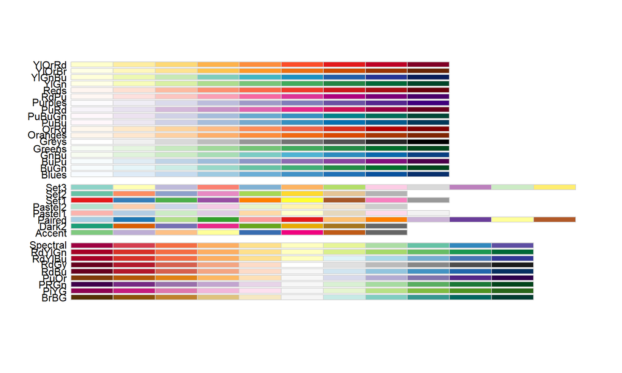

```r
display.brewer.all()
```

```r
gender_colors <- brewer.pal(4, "Set1")[3:4]
ticket_colors <- brewer.pal(10, "Spectral")[8:10]
survival_colors <- brewer.pal(3, "Set1")[1:2]
```

#1

Generate a series of bar charts to describe the gender, ticket class and survival of the passengers onboard

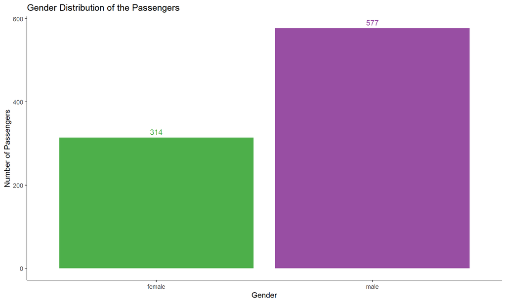

```r
############## GENDER ####################


#option 1
ggplot(df, aes(x = sex, fill = sex)) +
  geom_bar() +
  geom_text(stat = "count", aes(label = ..count..),
            vjust = -0.5,
            color = gender_colors) +
  scale_fill_manual(values = gender_colors) +
  labs(title = "Gender Distribution of the Passengers",
       x = "Gender",
       y = "Number of Passengers") +
  theme(
      legend.position = "none",
      panel.grid.major = element_blank(),
      panel.grid.minor = element_blank(),
      panel.background = element_rect(fill = "white"),
      axis.line = element_line(color = "black")
    )
```

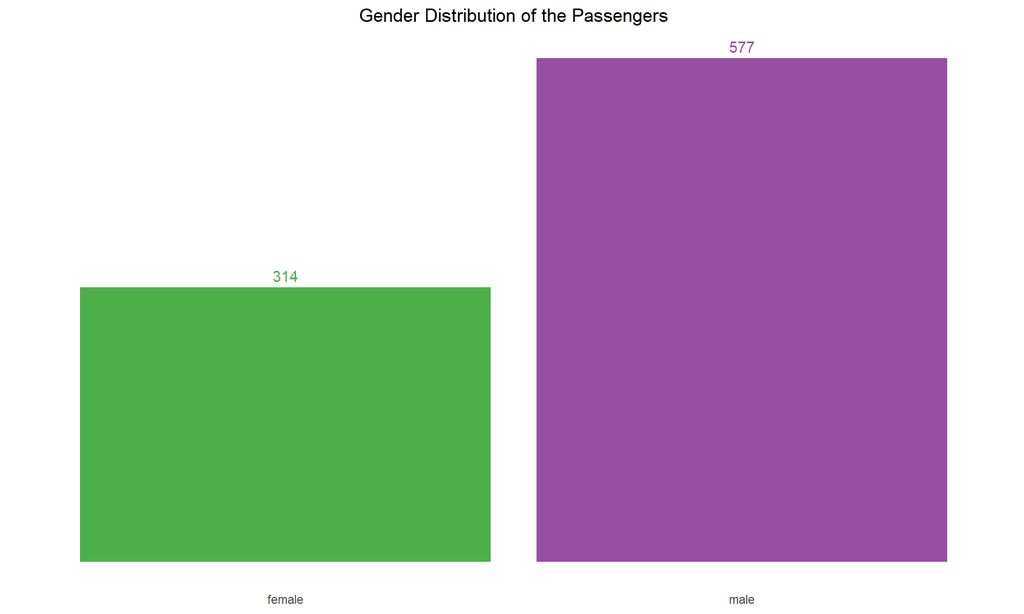

```r
#simpler
ggplot(df, aes(x = sex, fill = sex)) +
  geom_bar() +
  geom_text(stat = "count", aes(label = ..count..),
            vjust = -0.5,
            color = gender_colors) +
  scale_fill_manual(values = brewer.pal(4, "Set1")[3:4]) +
  labs(title = "Gender Distribution of the Passengers") +
  theme(
      plot.title = element_text(hjust = 0.5),
      legend.position = "none",
      panel.grid.major = element_blank(),
      panel.grid.minor = element_blank(),
      panel.background = element_rect(fill = "white"),
      axis.line.y = element_blank(),
      axis.text.y = element_blank(),
      axis.ticks.y = element_blank(),
      axis.title.y = element_blank(),
      axis.ticks.x = element_blank(),
      axis.line.x = element_blank(),
      axis.title.x = element_blank()
    )
```

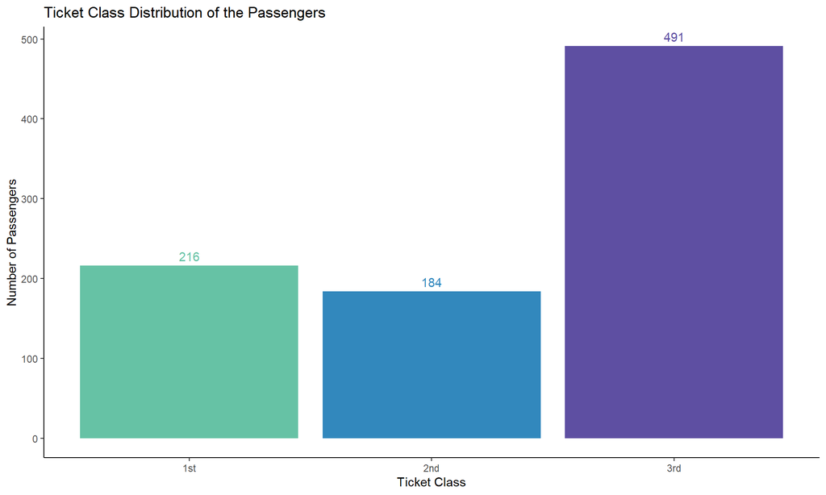

```r
############## TICKET CLASS ####################


ggplot(df, aes(x = factor(pclass,
                          levels = c(1, 2, 3),
                          labels = c("1st", "2nd", "3rd")),
       fill = factor(pclass))) +
  geom_bar() +
  geom_text(stat = "count", aes(label = ..count..),
            vjust = -0.5,
            color = ticket_colors) +
  scale_fill_manual(values = ticket_colors) +
  labs(title = "Ticket Class Distribution of the Passengers",
       x = "Ticket Class",
       y = "Number of Passengers") +
  theme(
      legend.position = "none",
      panel.grid.major = element_blank(),
      panel.grid.minor = element_blank(),
      panel.background = element_rect(fill = "white"),
      axis.line = element_line(color = "black")
    )
```

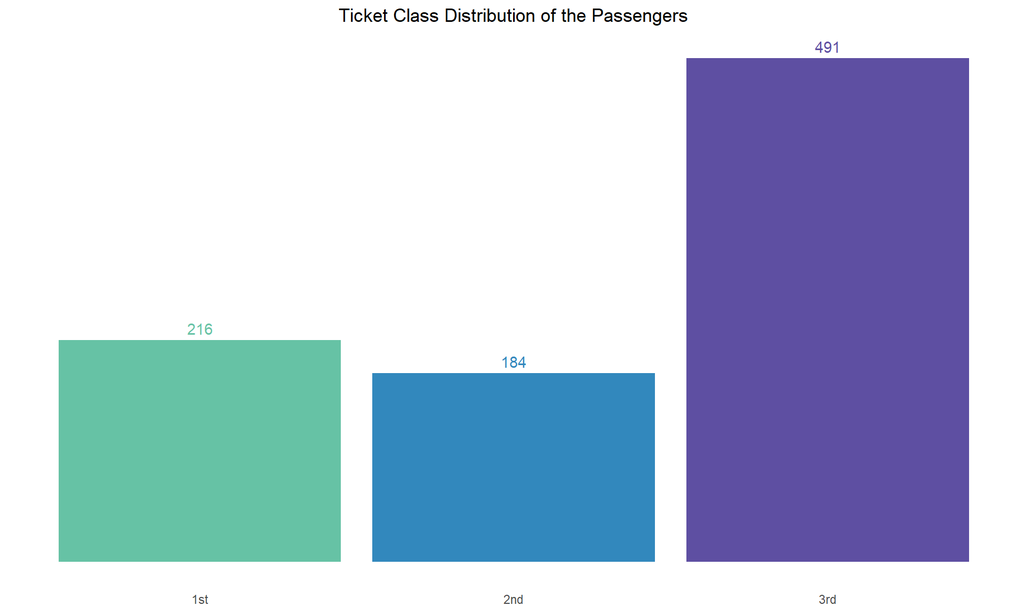

```r
#simpler
ggplot(df, aes(x = factor(pclass,
                          levels = c(1, 2, 3),
                          labels = c("1st", "2nd", "3rd")),
       fill = factor(pclass))) +
  geom_bar() +
  geom_text(stat = "count", aes(label = ..count..),
            vjust = -0.5,
            color = ticket_colors) +
  scale_fill_manual(values = ticket_colors) +
  labs(title = "Ticket Class Distribution of the Passengers") +
  theme(
      plot.title = element_text(hjust = 0.5),
      legend.position = "none",
      panel.grid.major = element_blank(),
      panel.grid.minor = element_blank(),
      panel.background = element_rect(fill = "white"),
      axis.line.y = element_blank(),
      axis.text.y = element_blank(),
      axis.ticks.y = element_blank(),
      axis.title.y = element_blank(),
      axis.ticks.x = element_blank(),
      axis.line.x = element_blank(),
      axis.title.x = element_blank()
    )
```

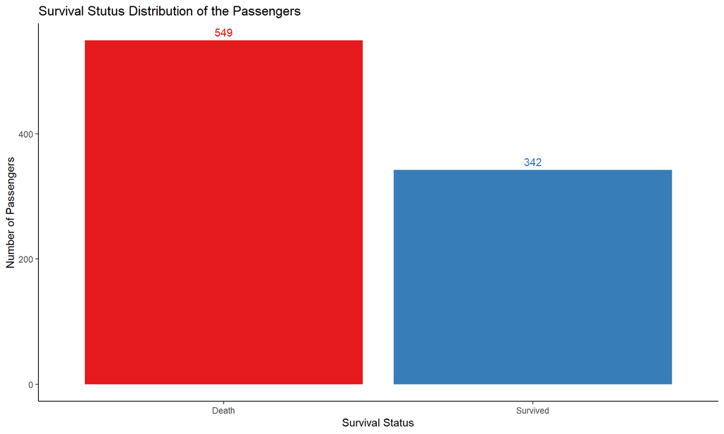

```r
############## SURVIVAL ####################

ggplot(df, aes(x = factor(survived,
                          levels = c(0, 1),
                          labels = c("Death", "Survived")),
               fill = factor(survived))) +
  geom_bar() +
  geom_text(stat = "count", aes(label = ..count..),
            vjust = -0.5,
            color = survival_colors) +
  scale_fill_manual(values = survival_colors) +
  labs(title = "Survival Stutus Distribution of the Passengers",
       x = "Survival Status",
       y = "Number of Passengers") +
  theme(
      legend.position = "none",
      panel.grid.major = element_blank(),
      panel.grid.minor = element_blank(),
      panel.background = element_rect(fill = "white"),
      axis.line = element_line(color = "black")
    )
```

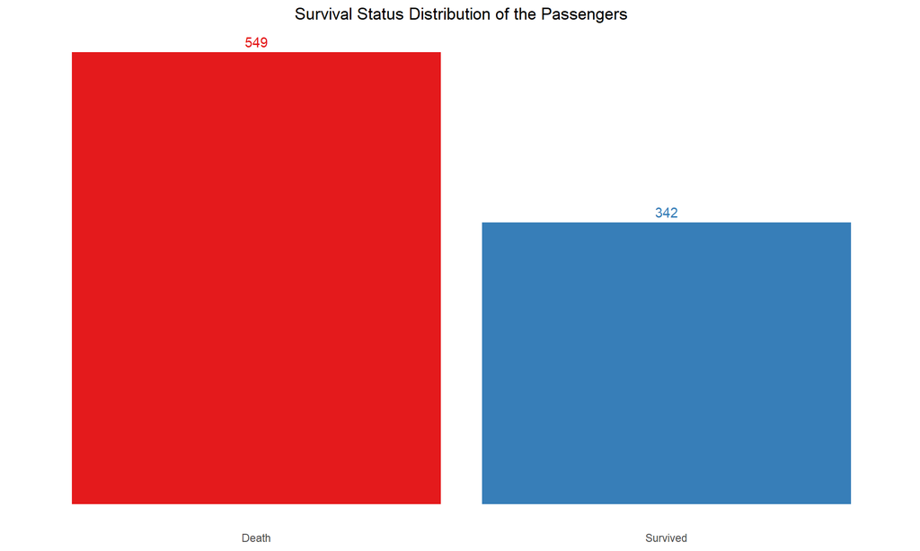

```r
#simpler
ggplot(df, aes(x = factor(survived,
                          levels = c(0, 1),
                          labels = c("Death", "Survived")),
               fill = factor(survived))) +
  geom_bar() +
  geom_text(stat = "count", aes(label = ..count..),
            vjust = -0.5,
            color = survival_colors) +
  scale_fill_manual(values = survival_colors) +
  labs(title = "Survival Status Distribution of the Passengers") +
  theme(
      plot.title = element_text(hjust = 0.5),
      legend.position = "none",
      panel.grid.major = element_blank(),
      panel.grid.minor = element_blank(),
      panel.background = element_rect(fill = "white"),
      axis.line.y = element_blank(),
      axis.text.y = element_blank(),
      axis.ticks.y = element_blank(),
      axis.title.y = element_blank(),
      axis.ticks.x = element_blank(),
      axis.line.x = element_blank(),
      axis.title.x = element_blank()
    )
```

#2 Generate a histogram for the passengers’ age. Furthermore, describe the passengers’ age using the following two boxplots: age per ticket class and age based on survival.

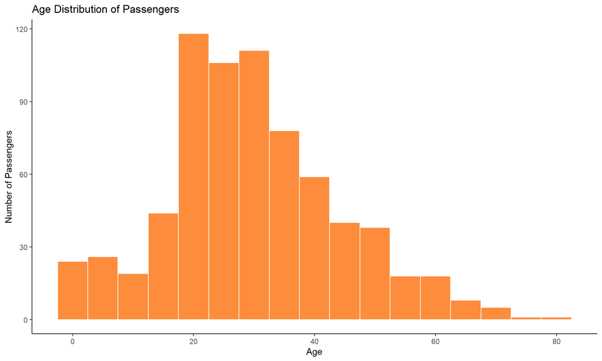

```r
############## HISTOGRAM ####################

ggplot(df, aes(x = age)) +
  geom_histogram(binwidth = 5, fill = brewer.pal(4, "YlOrRd")[3], color = "white") +
  labs(title = "Age Distribution of Passengers",
       x = "Age",
       y = "Number of Passengers") +
  theme(
      legend.position = "none",
      panel.grid.major = element_blank(),
      panel.grid.minor = element_blank(),
      panel.background = element_rect(fill = "white"),
      axis.line = element_line(color = "black")
    )
```

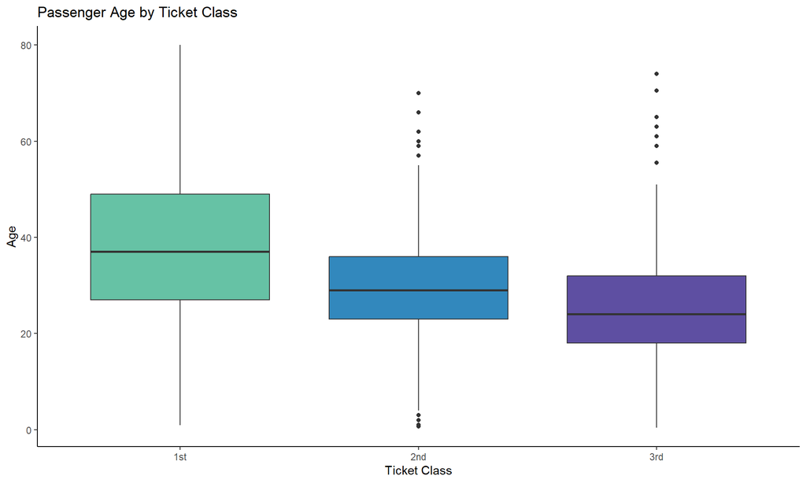

```r
############## BOXPLOT ticket class ####################

ggplot(df, aes(x = factor(pclass,
                          levels = c(1, 2, 3),
                          labels = c("1st", "2nd", "3rd")),
               y = age,
       fill = factor(pclass))) +
  geom_boxplot() +
  scale_fill_manual(values = ticket_colors) +
  labs(title = "Passenger Age by Ticket Class",
       x = "Ticket Class",
       y = "Age") +
  theme(
      legend.position = "none",
      panel.grid.major = element_blank(),
      panel.grid.minor = element_blank(),
      panel.background = element_rect(fill = "white"),
      axis.line = element_line(color = "black")
    )
```

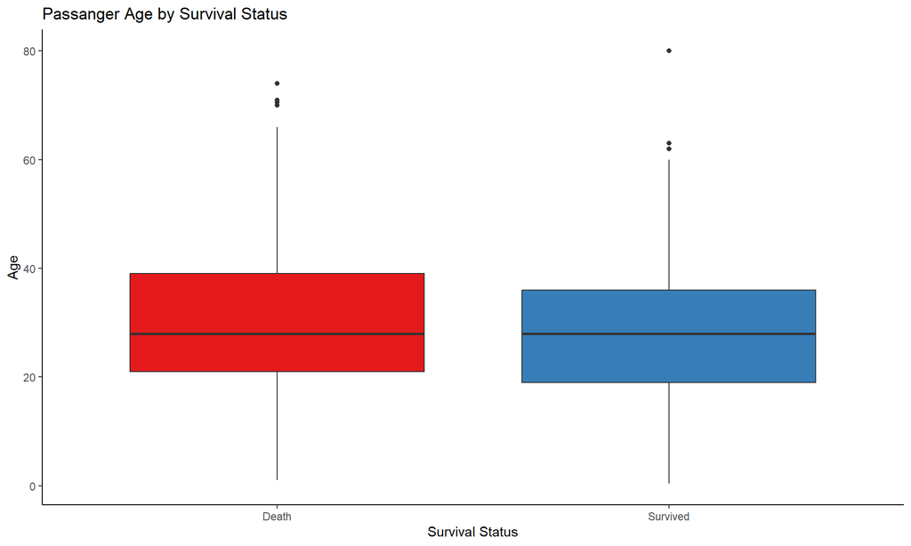

```r
############## BOXPLOT survival ####################

ggplot(df, aes(x = factor(survived,
                          levels = c(0, 1),
                          labels = c("Death", "Survived")),
               y = age,
               fill = factor(survived))) +
  geom_boxplot() +
  scale_fill_manual(values = survival_colors) +
  labs(title = "Passanger Age by Survival Status",
       x = "Survival Status",
       y = "Age") +
  theme(
      legend.position = "none",
      panel.grid.major = element_blank(),
      panel.grid.minor = element_blank(),
      panel.background = element_rect(fill = "white"),
      axis.line = element_line(color = "black")
    )
```

#3 Generate a histogram for the travel fare and a table showing the number of people who did not pay – you may want to check on Google why a handful of people was on board for free! ???

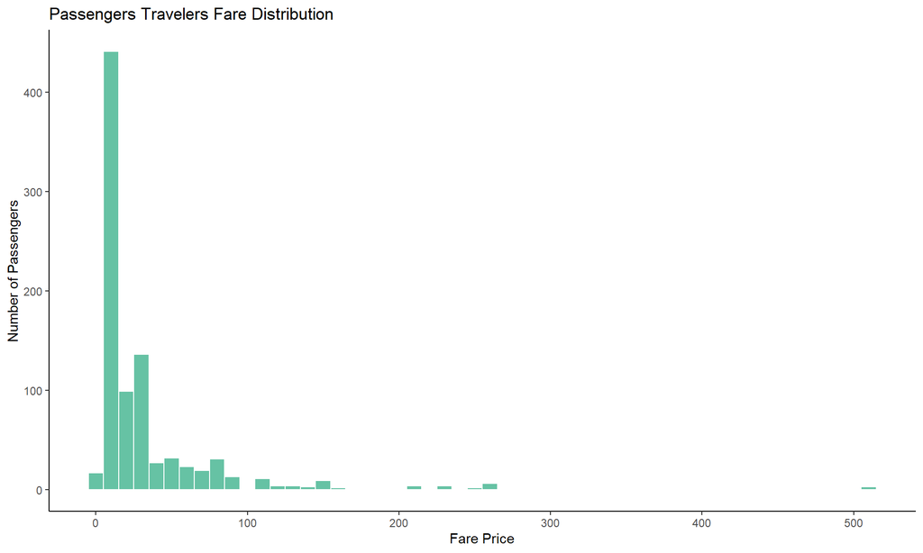

```r
############## HISTOGRAM ####################

ggplot(df, aes(x = fare)) +
  geom_histogram(binwidth = 10, fill = brewer.pal(4, "BuGn")[3], color = "white") +
  labs(title = "Passengers Travelers Fare Distribution",
       x = "Fare Price",
       y = "Number of Passengers") +
  theme(
      legend.position = "none",
      panel.grid.major = element_blank(),
      panel.grid.minor = element_blank(),
      panel.background = element_rect(fill = "white"),
      axis.line = element_line(color = "black")
    )
```

```r
############## TABLE ####################

fare_zero_table <- df %>%
  filter(fare == 0) %>%
  group_by(pclass, sex, age, survived) %>%
  summarise(Count = n(), .groups = "drop") %>%
  mutate(
    pclass = factor(pclass, levels = c(1, 2, 3), labels = c("1st", "2nd", "3rd")),
    survived = factor(survived, levels = c(0, 1), labels = c("Died", "Survived"))
  )

# Step 2: Add total row
fare_zero_total <- fare_zero_table %>%
  summarise(
    pclass = "Total",
    sex = "",
    age = NA,
    survived = "",
    Count = sum(Count)
  )

# Step 3: Bind rows together
fare_zero_combined <- bind_rows(fare_zero_table, fare_zero_total)

# Step 4: Display with kable
fare_zero_combined %>%
  kable(col.names = c("Ticket Class", "Sex", "Age", "Survival", "Number of Passengers"),
        caption = "Passengers Who Paid £0 Fare, by Class, Sex, Age, and Survival (with Total)") %>%
  kable_styling(bootstrap_options = c("striped", "condensed"), full_width = FALSE) %>%
  row_spec(0, bold = TRUE, background = brewer.pal(4, "BuGn")[3]) %>%
  row_spec(nrow(fare_zero_combined), bold = TRUE, background = "#f2f2f2")
```

Passengers Who Paid £0 Fare, by Class, Sex, Age, and Survival (with Total)

| Ticket Class | Sex | Age | Survival | Number of Passengers |
| --- | --- | --- | --- | --- |
| 1st | male | 38 | Died | 1 |
| 1st | male | 39 | Died | 1 |
| 1st | male | 40 | Died | 1 |
| 1st | male | NA | Died | 2 |
| 2nd | male | NA | Died | 6 |
| 3rd | male | 19 | Died | 1 |
| 3rd | male | 25 | Survived | 1 |
| 3rd | male | 36 | Died | 1 |
| 3rd | male | 49 | Died | 1 |
| Total |  | NA |  | 15 |

#4 A chart of your choice to describe the family size per ticket class

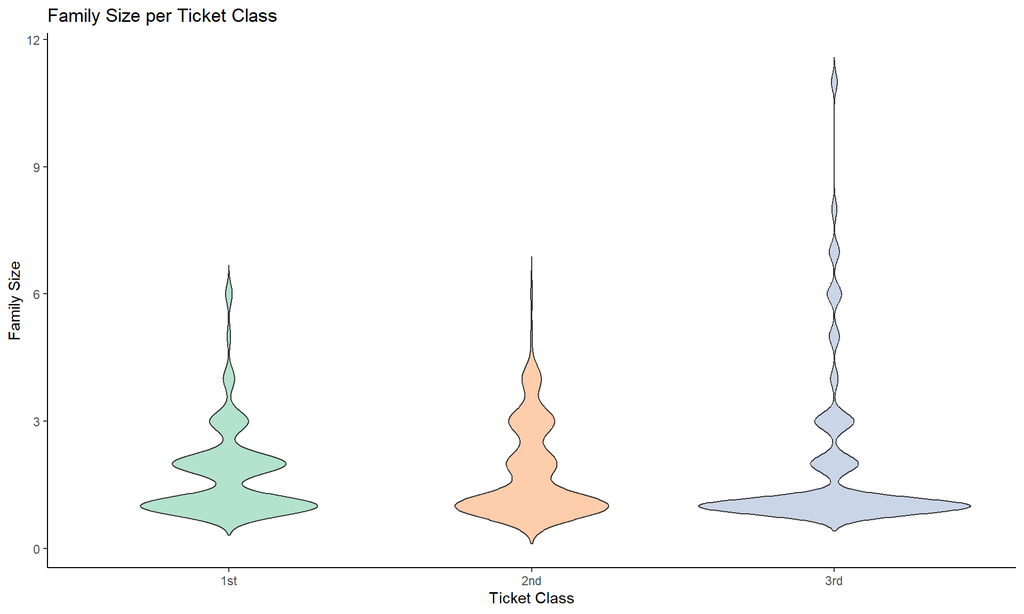

```r
############## violin ####################

# parch -> parents/children
# sibsp -> siblings/spouse
# +1 because of the passenger

df <- df %>%
  mutate(family_size = sibsp + parch + 1)



ggplot(df, aes(x = factor(pclass,
                          levels = c(1, 2, 3),
                          labels = c("1st", "2nd", "3rd")),
               y = family_size,
       fill = factor(pclass))) +
  geom_violin(trim = FALSE) +
  scale_fill_brewer(palette = "Pastel2") +
  labs(
    title = "Family Size per Ticket Class",
    x = "Ticket Class",
    y = "Family Size"
  ) +
  theme(
      legend.position = "none",
      panel.grid.major = element_blank(),
      panel.grid.minor = element_blank(),
      panel.background = element_rect(fill = "white"),
      axis.line = element_line(color = "black")
    )
```

#5 A series of stacked bar charts to show the how survival differs for different gender and ticket class

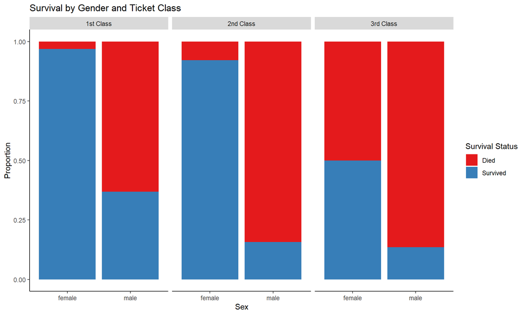

```r
############## proportion ####################
ggplot(df %>% mutate(
    pclass = factor(pclass, levels = c(1, 2, 3), labels = c("1st Class", "2nd Class", "3rd Class")),
    sex = factor(sex, levels = c("female", "male")),
    survived = factor(survived, levels = c(0, 1), labels = c("Died", "Survived"))
  ),
  aes(x = sex, fill = survived)) +
  geom_bar(position = "fill") +
  facet_wrap(~ pclass) +
  scale_fill_manual(values = survival_colors) +
  labs(
    title = "Survival by Gender and Ticket Class",
    x = "Sex",
    y = "Proportion",
    fill = "Survival Status"
  ) +
  theme(
      panel.grid.major = element_blank(),
      panel.grid.minor = element_blank(),
      panel.background = element_rect(fill = "white"),
      axis.line = element_line(color = "black")
    )
```

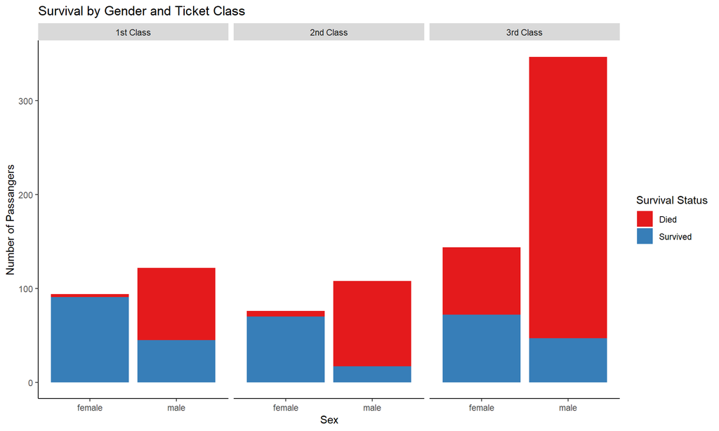

```r
############## count ####################
ggplot(df %>% mutate(
    pclass = factor(pclass, levels = c(1, 2, 3), labels = c("1st Class", "2nd Class", "3rd Class")),
    sex = factor(sex, levels = c("female", "male")),
    survived = factor(survived, levels = c(0, 1), labels = c("Died", "Survived"))
  ),
  aes(x = sex, fill = survived)) +
  geom_bar(position = "stack") +
  facet_wrap(~ pclass) +
  scale_fill_manual(values = survival_colors) +
  labs(
    title = "Survival by Gender and Ticket Class",
    x = "Sex",
    y = "Number of Passangers",
    fill = "Survival Status"
  ) +
  theme(
      panel.grid.major = element_blank(),
      panel.grid.minor = element_blank(),
      panel.background = element_rect(fill = "white"),
      axis.line = element_line(color = "black")
    )
```

#6 A violin chart describing how survival related to age and gender

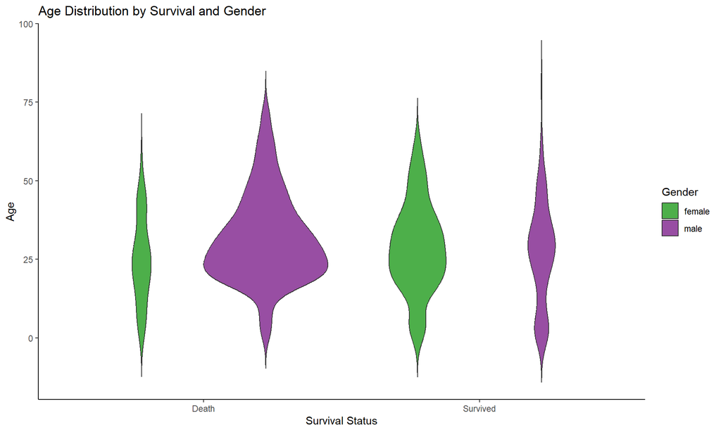

```r
############## legend gender ####################

#op 1 legend
ggplot(df %>% filter(!is.na(age)),
       aes(x = factor(survived,
                      levels = c(0, 1),
                      labels = c("Death", "Survived")),
           y = age,
           fill = sex)) +
  geom_violin(trim = FALSE, scale = "count") +

  labs(
    title = "Age Distribution by Survival and Gender",
    x = "Survival Status",
    y = "Age",
    fill = "Gender"
  ) +
  scale_fill_manual(values = gender_colors) +
  theme(
      panel.grid.major = element_blank(),
      panel.grid.minor = element_blank(),
      panel.background = element_rect(fill = "white"),
      axis.line = element_line(color = "black")
    )
```

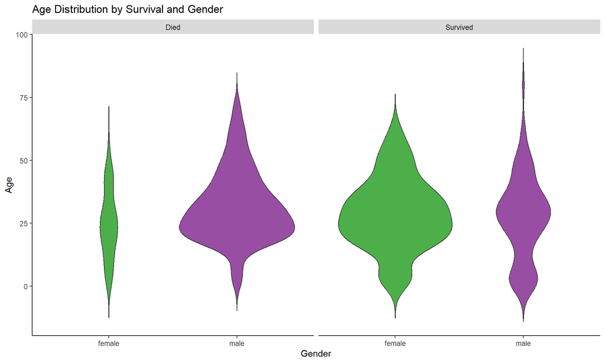

```r
#op 2 no legend, facet wrap
ggplot(df %>% filter(!is.na(age)) %>%
         mutate(
           sex = factor(sex, levels = c("female", "male")),
           survived = factor(survived, levels = c(0, 1), labels = c("Died", "Survived"))
         ),
       aes(x = sex,
           y = age,
           fill = sex)) +
  geom_violin(trim = FALSE, scale = "count") +
  facet_wrap(~ survived) +
  labs(
    title = "Age Distribution by Survival and Gender",
    x = "Gender",
    y = "Age",
    fill = "Gender"
  ) +
  scale_fill_manual(values = gender_colors) +
  theme(
      legend.position = "none",
      panel.grid.major = element_blank(),
      panel.grid.minor = element_blank(),
      panel.background = element_rect(fill = "white"),
      axis.line = element_line(color = "black")
    )
```

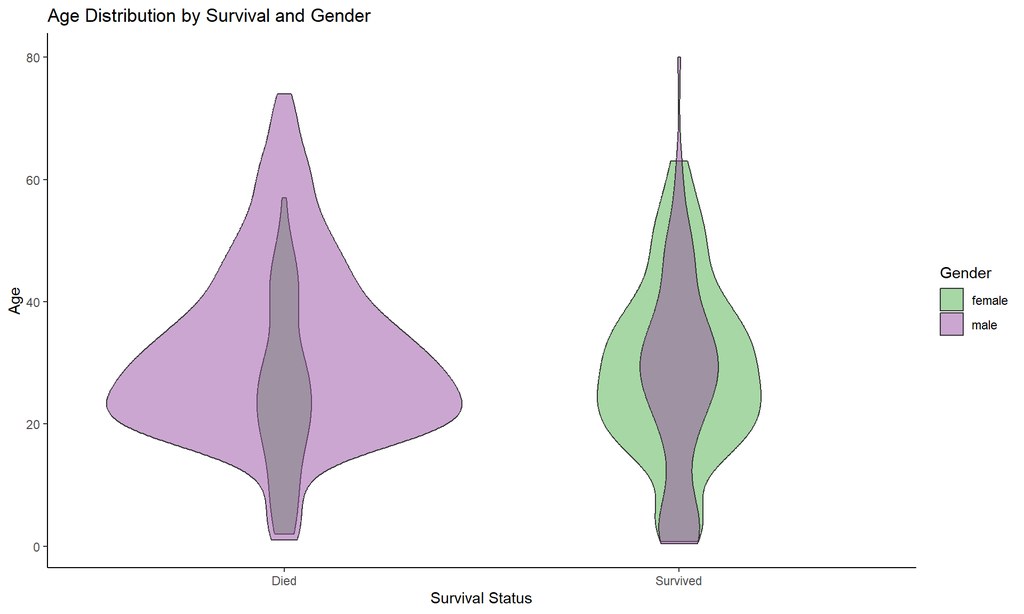

```r
#op 3 overlap
ggplot(df %>% filter(!is.na(age)) %>%
         mutate(
           sex = factor(sex, levels = c("female", "male")),
           survived = factor(survived, levels = c(0, 1), labels = c("Died", "Survived"))
         ),
       aes(x = survived, y = age, fill = sex)) +
  geom_violin(trim = TRUE, scale = "count", position = "identity", alpha = 0.5) +
  labs(
    title = "Age Distribution by Survival and Gender",
    x = "Survival Status",
    y = "Age",
    fill = "Gender"
  ) +
  scale_fill_manual(values = gender_colors) +
  theme(
    panel.grid.major = element_blank(),
    panel.grid.minor = element_blank(),
    panel.background = element_rect(fill = "white"),
    axis.line = element_line(color = "black")
  )
```

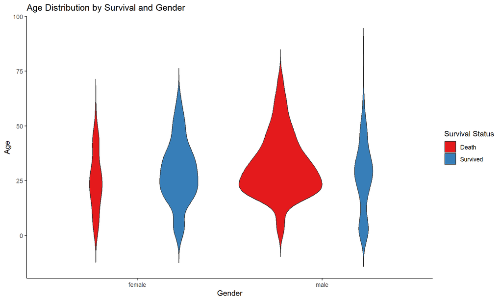

```r
############## legend survival ####################

#op 1 legend
ggplot(df %>% filter(!is.na(age)),
       aes(x = sex,
           y = age,
           fill = factor(survived,
                      levels = c(0, 1),
                      labels = c("Death", "Survived")))) +
  geom_violin(trim = FALSE, scale = "count") +
  labs(
    title = "Age Distribution by Survival and Gender",
    x = "Gender",
    y = "Age",
    fill = "Survival Status"
  ) +
  scale_fill_manual(values = survival_colors) +
  theme(
      panel.grid.major = element_blank(),
      panel.grid.minor = element_blank(),
      panel.background = element_rect(fill = "white"),
      axis.line = element_line(color = "black")
    )
```

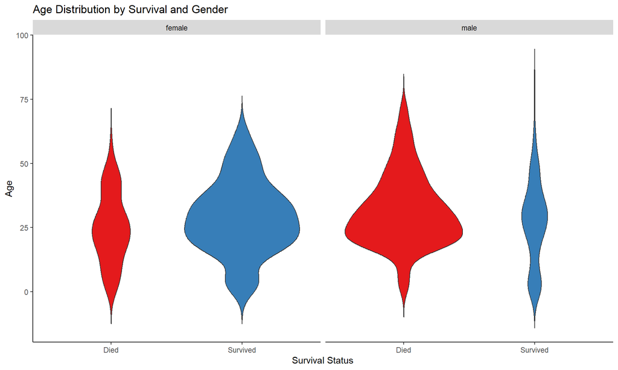

```r
#op 2 no legend face wrap
ggplot(df %>% filter(!is.na(age)) %>%
         mutate(
           sex = factor(sex, levels = c("female", "male")),
           survived = factor(survived, levels = c(0, 1), labels = c("Died", "Survived"))
         ),
       aes(x = survived,
           y = age,
           fill = survived)) +
  geom_violin(trim = FALSE, scale = "count") +
  facet_wrap(~ sex) +
  labs(
    title = "Age Distribution by Survival and Gender",
    x = "Survival Status",
    y = "Age",
    fill = "Gender"
  ) +
  scale_fill_manual(values = survival_colors) +
  theme(
      legend.position = "none",
      panel.grid.major = element_blank(),
      panel.grid.minor = element_blank(),
      panel.background = element_rect(fill = "white"),
      axis.line = element_line(color = "black")
    )
```

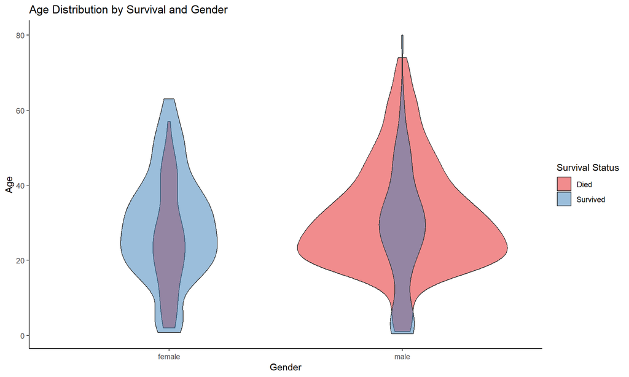

```r
#op 3 overlap
ggplot(df %>% filter(!is.na(age)) %>%
         mutate(
           sex = factor(sex, levels = c("female", "male")),
           survived = factor(survived, levels = c(0, 1), labels = c("Died", "Survived"))
         ),
       aes(x = sex, y = age, fill = survived)) +
  geom_violin(trim = TRUE, scale = "count", position = "identity", alpha = 0.5) +
  labs(
    title = "Age Distribution by Survival and Gender",
    x = "Gender",
    y = "Age",
    fill = "Survival Status"
  ) +
  scale_fill_manual(values = survival_colors) +
  theme(
      panel.grid.major = element_blank(),
      panel.grid.minor = element_blank(),
      panel.background = element_rect(fill = "white"),
      axis.line = element_line(color = "black")
  )
```

#7 A violin chart describing the survival rate related to age and ticket class

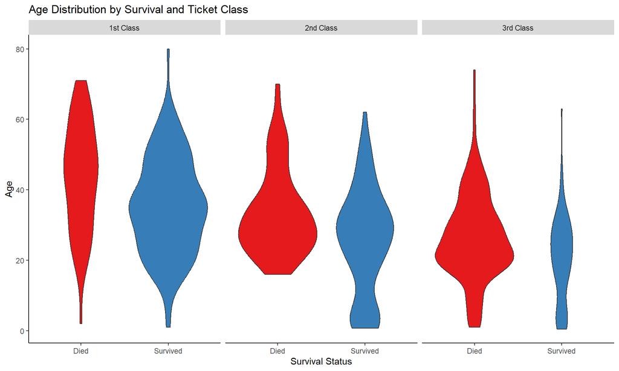

```r
#op 1 x survived
ggplot(df %>% filter(!is.na(age)) %>%
         mutate(
                survived = factor(survived,
                                  levels = c(0, 1),
                                  labels = c("Died", "Survived")),
                pclass = factor(pclass,
                                levels = c(1, 2, 3),
                                labels = c("1st Class", "2nd Class", "3rd Class"))),
  aes(x = survived, y = age, fill = survived)) +
  geom_violin(trim = TRUE, scale = "count") +
  facet_wrap(~ pclass) +
  scale_fill_manual(values = survival_colors) +
  labs(
    title = "Age Distribution by Survival and Ticket Class",
    x = "Survival Status",
    y = "Age",
    fill = "Survival"
  ) +
  theme(
      legend.position = "none",
      panel.grid.major = element_blank(),
      panel.grid.minor = element_blank(),
      panel.background = element_rect(fill = "white"),
      axis.line = element_line(color = "black")
  )
```

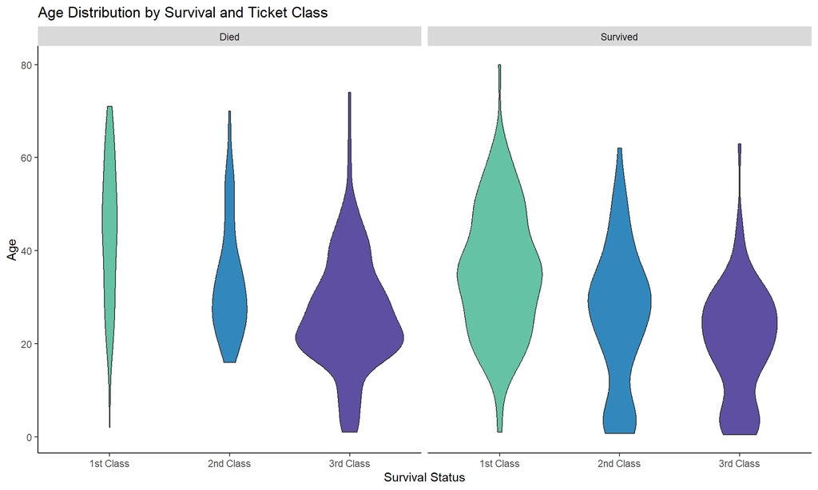

```r
#op 2 x class
ggplot(df %>% filter(!is.na(age)) %>%
         mutate(
                survived = factor(survived,
                                  levels = c(0, 1),
                                  labels = c("Died", "Survived")),
                pclass = factor(pclass,
                                levels = c(1, 2, 3),
                                labels = c("1st Class", "2nd Class", "3rd Class"))),
  aes(x = pclass, y = age, fill = pclass)) +
  geom_violin(trim = TRUE, scale = "count") +
  facet_wrap(~ survived) +
  scale_fill_manual(values = ticket_colors) +
  labs(
    title = "Age Distribution by Survival and Ticket Class",
    x = "Survival Status",
    y = "Age",
    fill = "Survival"
  ) +
  theme(
      legend.position = "none",
      panel.grid.major = element_blank(),
      panel.grid.minor = element_blank(),
      panel.background = element_rect(fill = "white"),
      axis.line = element_line(color = "black")
  )
```

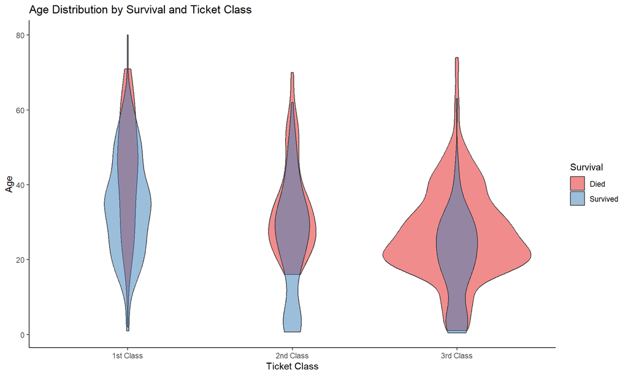

```r
#op 3 overlap, x class
ggplot(df %>% filter(!is.na(age)) %>%
         mutate(
                survived = factor(survived,
                                  levels = c(0, 1),
                                  labels = c("Died", "Survived")),
                pclass = factor(pclass,
                                levels = c(1, 2, 3),
                                labels = c("1st Class", "2nd Class", "3rd Class"))),
  aes(x = pclass, y = age, fill = survived)) +
  geom_violin(trim = TRUE, scale = "count", position = "identity", alpha = 0.5) +
  scale_fill_manual(values = survival_colors) +
  labs(
    title = "Age Distribution by Survival and Ticket Class",
    x = "Ticket Class",
    y = "Age",
    fill = "Survival"
  ) +
  theme(
      panel.grid.major = element_blank(),
      panel.grid.minor = element_blank(),
      panel.background = element_rect(fill = "white"),
      axis.line = element_line(color = "black")
  )
```

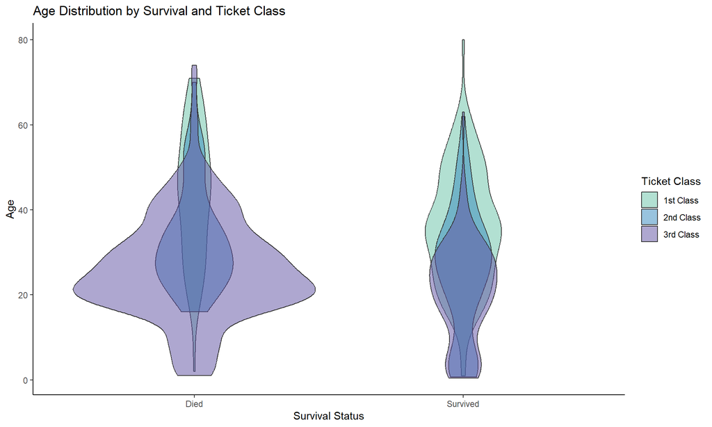

```r
#op 4 overlap, x survival
#unreadable but prettyyyy :)

ggplot(df %>% filter(!is.na(age)) %>%
         mutate(
                survived = factor(survived,
                                  levels = c(0, 1),
                                  labels = c("Died", "Survived")),
                pclass = factor(pclass,
                                levels = c(1, 2, 3),
                                labels = c("1st Class", "2nd Class", "3rd Class"))),
  aes(x = survived, y = age, fill = pclass)) +
  geom_violin(trim = TRUE, scale = "count", position = "identity", alpha = 0.5) +
  scale_fill_manual(values = ticket_colors) +
  labs(
    title = "Age Distribution by Survival and Ticket Class",
    x = "Survival Status",
    y = "Age",
    fill = "Ticket Class"
  ) +
  theme(
      panel.grid.major = element_blank(),
      panel.grid.minor = element_blank(),
      panel.background = element_rect(fill = "white"),
      axis.line = element_line(color = "black")
  )
```

#From the graphs above, what kind of associations between the variables like age, gender, ticket class and the survival do you observe?

Overall there were more males and passengers in 3rd class Males died more than females

Comparing ticket classes: majority of male died independently of ticket class, but the proportion of deaths increases majority of female survived, but again the proportion of deaths increases as class is worse, reachinga around 50/50 in 3rd class

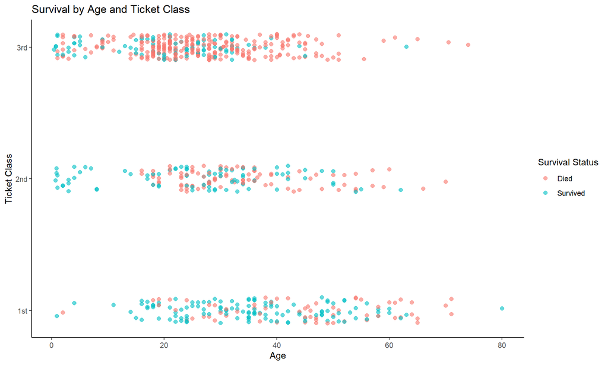

```r
ggplot(df %>% filter(!is.na(age)) %>%
  mutate(
    survived_num = as.numeric(as.character(survived)),
    pclass_num = as.numeric(as.character(pclass)),
    pclass = factor(pclass, levels = c(1, 2, 3), labels = c("1st", "2nd", "3rd")),
    survived = factor(survived, levels = c(0, 1), labels = c("Died", "Survived"))
  ),
  aes(x = age, y = pclass_num, color = survived)) +
  geom_jitter(height = 0.1, width = 0, alpha = 0.6, size = 2) +
  scale_y_continuous(breaks = c(1, 2, 3), labels = c("1st", "2nd", "3rd")) +
  scale_fill_manual(values = survival_colors) +
  labs(
    title = "Survival by Age and Ticket Class",
    x = "Age",
    y = "Ticket Class",
    color = "Survival Status"
  ) +
  theme(
      panel.grid.major = element_blank(),
      panel.grid.minor = element_blank(),
      panel.background = element_rect(fill = "white"),
      axis.line = element_line(color = "black")
  )
```